# Visualization of recurrent event data

Sy Han (Steven) Chiou

2020-08-17

In this vignette, we demonstrate how to create a `reSurv` object in **`reReg`** package. The `reSurv` object is then used to create event plots and mean cumulative function (MCF) plots. We will illustrate the usage of our functions with the `readmission` data from the **`frailtypack`** package (Rondeau, Mazroui, and Gonzalez 2012, González Ruiz et al. (2005)). The data contains re-hospitalization times after surgery in patients diagnosed with colorectal cancer. In this data set, the recurrent event is the readmission and the terminal event is either death or end of study. See `?readmission` for data details.

```r
> library(reReg)
> packageVersion("reReg")
```

```
[1] '1.3.1'
```

```r
> data(readmission, package = "frailtypack")
> head(readmission)
```

```
  id enum t.start t.stop time event      chemo    sex dukes charlson death
1  1    1       0     24   24     1    Treated Female     D        3     0
2  1    2      24    457  433     1    Treated Female     D        0     0
3  1    3     457   1037  580     0    Treated Female     D        0     0
4  2    1       0    489  489     1 NonTreated   Male     C        0     0
5  2    2     489   1182  693     0 NonTreated   Male     C        0     0
6  3    1       0     15   15     1 NonTreated   Male     C        3     0
```

```r
> readmission <- subset(readmission, !(id %in% c(60, 109, 280)))
> attach(readmission)
```

## `reSurv`/`Recur` objects

```r
> args(reSurv)
```

```
function (time1, time2, id, event, status, origin = 0)
NULL
```

- `time1` starting time for the gap time between two successive recurrent events
- `time2` ending time for the gap time between two successive recurrent events
- `id` subject's id
- `event` a vector used as the recurrent event indicator; `event = 0` for non-recurrent times (such as the censoring times)
- `status` a binary vector used as the status indicator for the terminal event; `status = 0` for censored time
- `origin` a numerical vector indicating the time origin of subjects

The arguments of `Recur()` are similar to those of `reSurv()`. They are listed as follow

```r
> args(Recur)
```

```
function (time, id, event, terminal, origin, check = c("hard",
    "soft", "none"), ...)
NULL
```

The six arguments are as follows

- `time` is a numerical vector representing the time of recurrence event or censoring, or a list with elements named `time1` and `time2` for specifying the follow-up of recurrent events. In the latter case, function `%to%` (or `%2%`) can be used to construct such list. In addition to numeric values, `Date` and `difftime` are allowed and converted to numeric values. An error will be thrown if this argument is not specified.
- `id` specifies the subject identity. It can be numeric vector, character vector, or a factor vector. If it is left unspecified, `Recur()` will assume that each row represents a subject.
- `event` is a numeric vector that represents the types of the recurrent events. Logical vector is allowed and converted to numeric vector. Non-positive values are internally converted to zero indicating censoring status.
- `terminal` is a numeric vector that represents the status of the terminal event. Logical vector is allowed and converted to numeric vector. Non-positive values are internally converted to zero indicating censoring status. If a scalar value is specified, all subjects will have the same status of terminal events at their last recurrent episodes. The length of the specified `terminal` should be equal to the number of subjects, or number of data rows. In the latter case, each subject may have at most one positive entry of `terminal` at the last recurrent episode.
- `origin` a numerical vector indicating the time origin of each subject. If a scalar value is specified, all subjects will have the same origin at the specified value. The length of the specified `origin` should be equal to the number of subjects, or number of data rows. In the latter case, different subjects may have different origins. However, one subject must have the same origin. In addition to numeric values, `Date` and `difftime` are also supported and converted to numeric values.
- `check` is a character value specifying how to perform the checks for recurrent event data. Errors or warnings will be thrown, respectively, if the `check` is specified to be `"hard""’"` (default) or `"soft""’"`. If `check = "none"` is specified, no data checking procedure will be run.

The main arguments of `Recur()` come directly from `reSurv()`, but `Recur()` comes with a comprehensive check for recurrent event data. Moreover, `Recur()` returns a `S4` class object that can be used for functions in both the `reReg` package and the `reda` package. Readers are referred to a separate [vignette on `Recur()`](https://wenjie-stat.me/reda/articles/reda-recur) for a detailed introduction of `Recur()`.

```r
> invisible(reSurv(t.stop, id, event, death))
```

```
Warning in reSurv(t.stop, id, event, death): 'reSurv()' is being deprecated in Version 1.1.7. Output is prepared by 'Recur()'.
 See '?Recur()' for details.
```

```r
> identical(suppressWarnings(reSurv(t.stop, id, event, death)), Recur(t.stop, id, event, death))
```

[output not shown]

The usage of `Recur()` is very similar to that of `reSurv()`, but the former is more flexible and offers much more features. In the following, we introduce different ways to create an `Recur` object. When the starting times and the ending times of recurrent events are known one can specify both times in `Recur()` as a list constructed by `%to%` (or its alias `%2%`).

```r
> Recur(t.start %to% t.stop, id = id, event = event, status = death)
```

When the starting times are identical throughout subjects and are equal to zero, it is sufficient only to specify the end times in `time`.

```r
> Recur(time = t.stop, id = id, event = event, status = death)
```

The identical `Recur` objects can be achieved without specifying the argument names:

```r
> Recur(t.start %to% t.stop, id, event, death)
> Recur(t.stop, id, event, death)
```

For each subject, the function `Recur()` prints intervals to represent the duration until the next event (a recurrent event or a terminal event).

```r
> Recur(t.stop, id, event, death)
```

```
...
  [1] 1: (0, 24], (24, 457], (457, 1037+]
  [2] 2: (0, 489], (489, 1182+]
  [3] 3: (0, 15], (15, 783*]
  [4] 4: (0, 163], (163, 288], ..., (686, 2048+]
  [5] 5: (0, 1134], (1134, 1144+]
  [6] 6: (0, 627], (627, 1190], ..., (1406, 1407+]
  [7] 7: (0, 38], (38, 42], ..., (63, 1049+]
  [8] 8: (0, 1466*]
  [9] 9: (0, 148], (148, 1474+]
 [10] 10: (0, 1113+]
 [11] 11: (0, 267], (267, 276], (276, 1635+]
 [12] 12: (0, 1189+]
 [13] 13: (0, 1028], (1028, 1207+]
 [14] 14: (0, 1125+]
 [15] 15: (0, 734], (734, 892], (892, 893*]
...
```

The example above shows patient id #1 experienced 2 readmission with a terminal event at `t = 1037` (days). The `+` at `t = 1037` indicates the terminal time was censored, e.g., this patient did not experience the event of interest (death) at `t = 1037`. Similarly, patient id #3 has one readmission and died at `t = 783` (days) as indicated by `*` at `783`. On the other hand patient id # 4 has more than 3 readmissions and was censored at `t = 2048` (days). The readmission intervals was suppressed to prevent printing results wider than the screen allowance. The number of intervals to be printed can be tuned using the `options` and argument `reda.Recur.maxPrint`. For example,

```r
> options(reda.Recur.maxPrint = 6)
> Recur(t.stop, id, event, death)
```

```
...
  [1] 1: (0, 24], (24, 457], (457, 1037+]
  [2] 2: (0, 489], (489, 1182+]
  [3] 3: (0, 15], (15, 783*]
  [4] 4: (0, 163], (163, 288], (288, 638], (638, 686], (686, 2048+]
  [5] 5: (0, 1134], (1134, 1144+]
  [6] 6: (0, 627], (627, 1190], (1190, 1406], (1406, 1407+]
  [7] 7: (0, 38], (38, 42], (42, 63], (63, 1049+]
  [8] 8: (0, 1466*]
  [9] 9: (0, 148], (148, 1474+]
 [10] 10: (0, 1113+]
 [11] 11: (0, 267], (267, 276], (276, 1635+]
 [12] 12: (0, 1189+]
 [13] 13: (0, 1028], (1028, 1207+]
 [14] 14: (0, 1125+]
 [15] 15: (0, 734], (734, 892], (892, 893*]
...
```

## Event plots

Event plots are a quick and easy way to glance at recurrent event data. These can be produced by plotting the `Recur` object with `R`'s generic function `plot()`, shown in Figure 1.

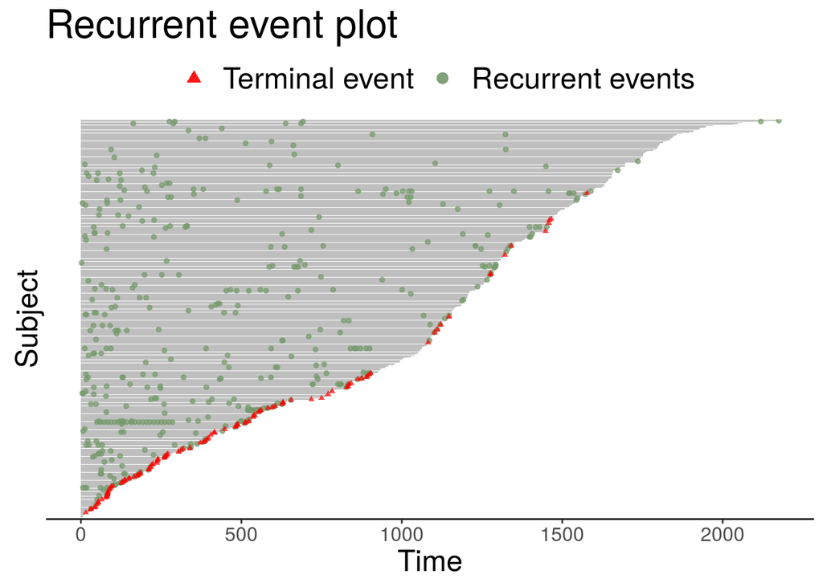

Figure 1: Creating an event plot from a `Recur` object.

```r
> reObj <- Recur(t.stop, id, event, death)
> plot(reObj)
```

Common graphical options like `xlab`, `ylab`, `main`, and more can be directly passed down to `plot()`.

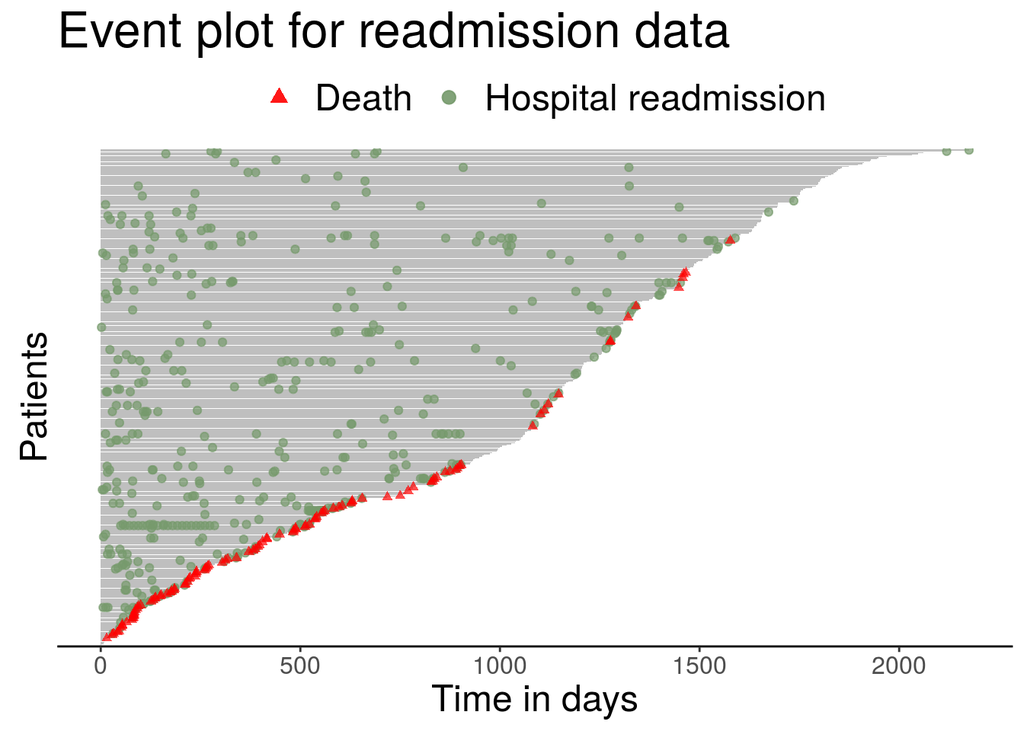

Figure 2: Creating an event plot from a `Recur` object with custom labels.

```r
> plot(reObj, cex = 1.5, xlab = "Time in days", ylab = "Patients",
+      main = "Event plot for readmission data",
+      terminal.name = "Death",
+      recurrent.name = "Hospital readmission")
```

Separate (stratified) event plots can be produced with the `plotEvents` function, which is a more specialized function for event plots. To demonstrate this, we first detach `readmission`.

```r
> detach(readmission)
```

Unlike the generic plot function, `plotEvents()` uses a formula object to specify the stratification.

```r
> args(plotEvents)
```

```
function (formula, data, result = c("increasing", "decreasing",
    "asis"), control = list(), ...)
NULL
```

Here are some examples to re-create Figure 1 with `plotEvents()`:

```r
> plotEvents(reObj)
> plotEvents(reObj, data = readmission)
> plotEvents(reObj ~ 1, data = readmission)
> plotEvents(Recur(t.stop, id, event, death) ~ 1, data = readmission)
```

Figure 2 can be re-created with `plotEvents` in a similar fashion:

```r
> plotEvents(Recur(t.stop, id, event, death) ~ 1, data = readmission,
+            cex = 1.5, xlab = "Time in days", ylab = "Patients",
+            main = "Event plot for readmission data",
+            terminal.name = "Death", recurrent.name = "Hospital readmission")
```

The `plotEvents()` function can also stratify event plots by groups. For example, the following can be used to stratify an event plot by `sex`.

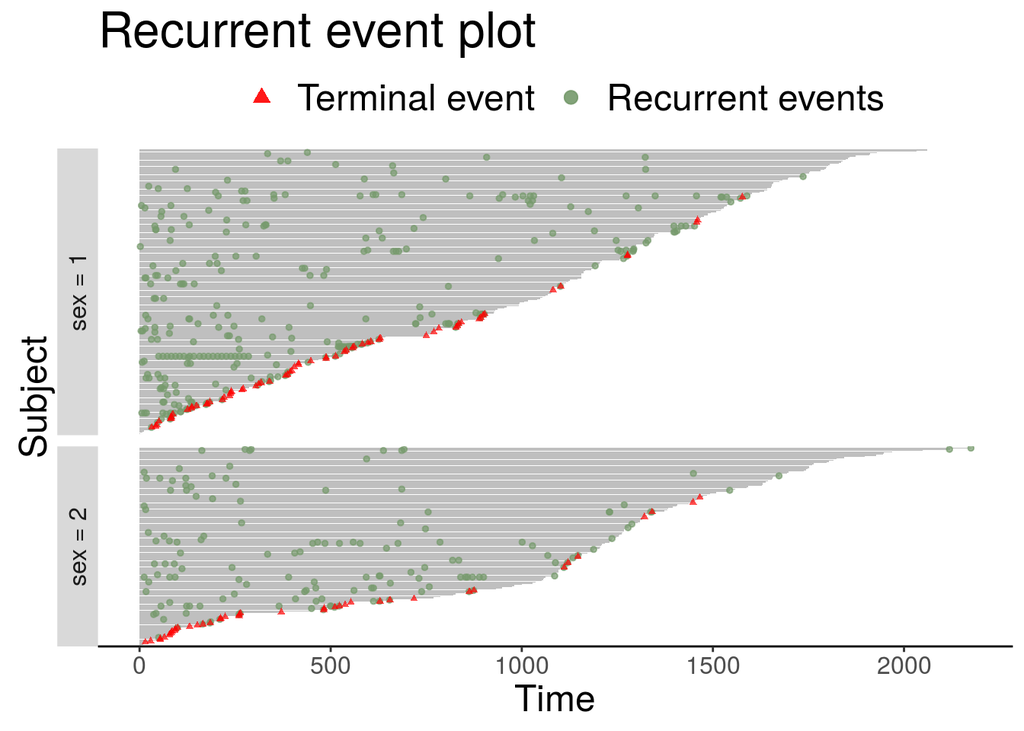

Figure 3: Event plot grouped by `sex`

```r
> plotEvents(Recur(t.stop, id, event, death) ~ sex, data = readmission)
```

Event plot by `sex` and `chemo`:

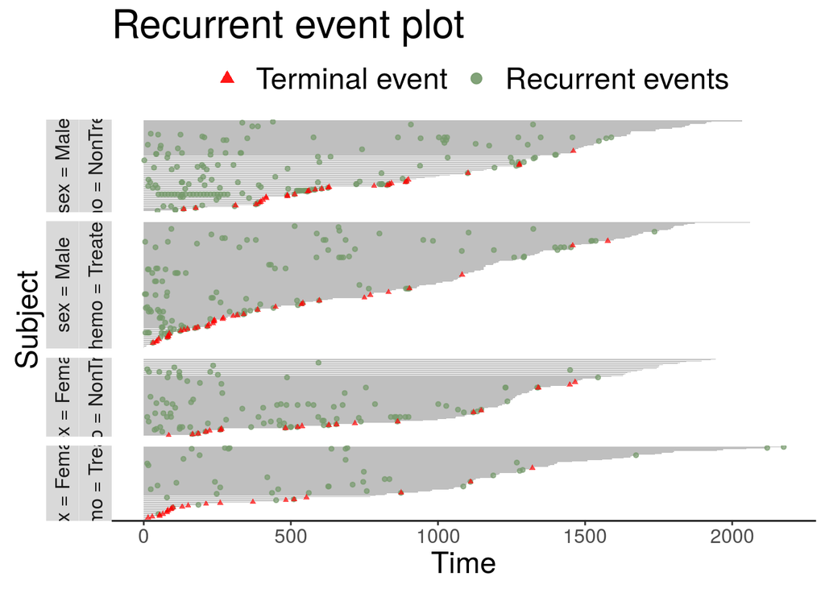

Figure 4: Event plot grouped by `sex` and `chemo`.

```r
> plotEvents(Recur(t.stop, id, event, death) ~ sex + chemo, data = readmission)
```

## MCF plots

The MCF plot can be created with `R`'s generic function `plot()`, shown in Figure 5.

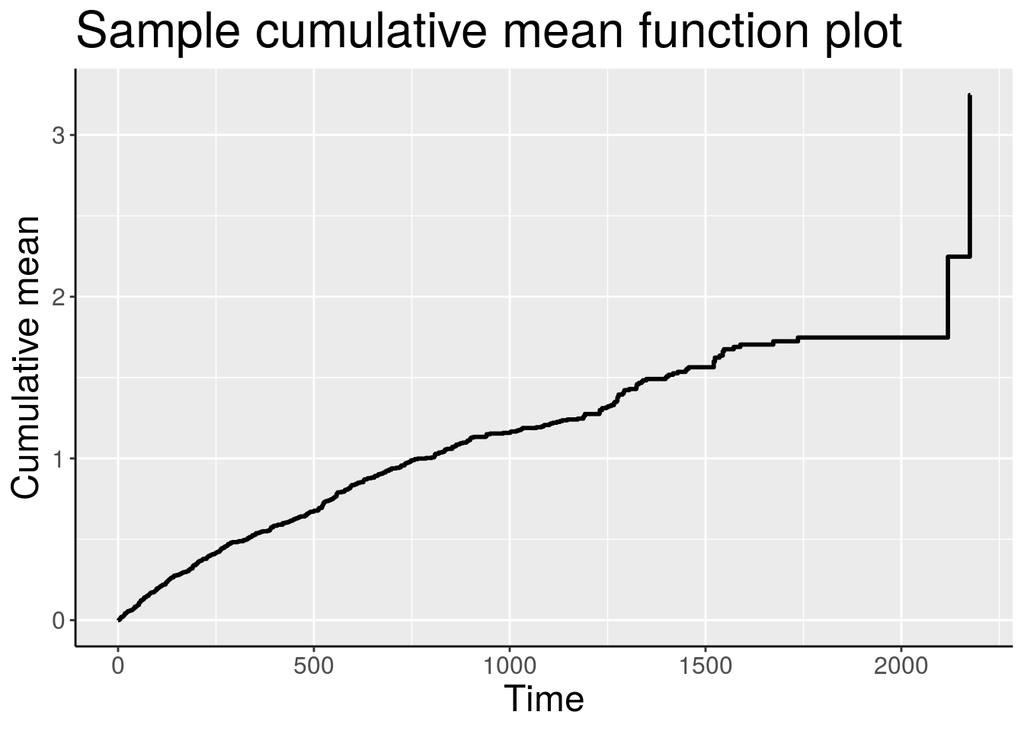

Figure 5: Creating a MCF plot from a `Recur` object.

```r
> plot(reObj, mcf = TRUE)
```

The MCF plot can be created with the more specialized function, `plotMCF()`. Both `plotEvents()` and `plotMCF()` return **`ggplot2`** objects. A side-by-side MCF plot, showing the MCF functions with and without risk adjustment, is shown in Figure 6.

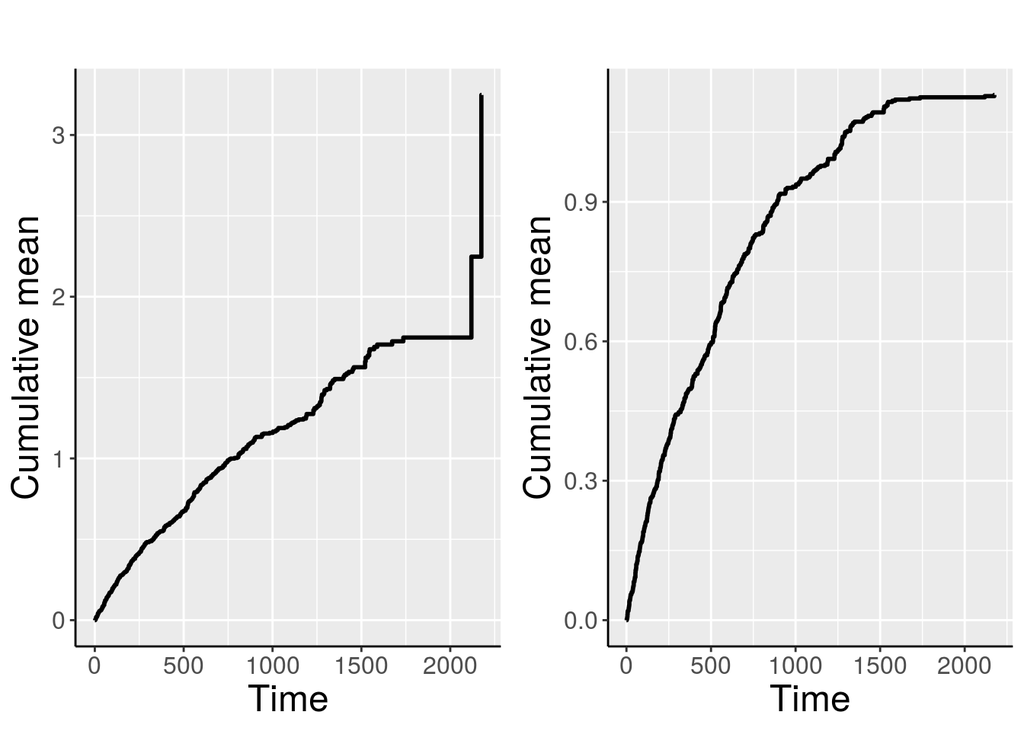

Figure 6: Creating a MCF plot from a `Recur` object.

```r
> library(gridExtra)
> p1 <- plotMCF(Recur(t.stop, id, event, death) ~ 1, data = readmission, main = "")
> p2 <- plotMCF(Recur(t.stop, id, event, death) ~ 1, data = readmission,
+               adjrisk = FALSE, main = "")
> grid.arrange(p1, p2, ncol=2)
```

As with the `plotEvents()`, `plotMCF()` can generate MCF plots given covariates. Figure 7 depicts the MCF plots grouped by `sex`.

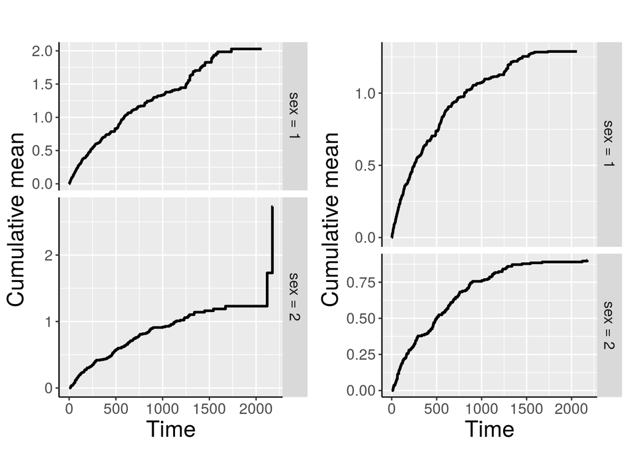

Figure 7: MCF plot grouped by `sex`.

```r
> p1 <- plotMCF(Recur(t.stop, id, event, death) ~ sex, data = readmission, main = "")
> p2 <- plotMCF(Recur(t.stop, id, event, death) ~ sex, data = readmission,
+               adjrisk = FALSE, main = "")
> grid.arrange(p1, p2, ncol=2)
```

As in `plotEvents()`, the more complicated Figure 8 depicts the MCF plots grouped by `sex` and `chemo`.

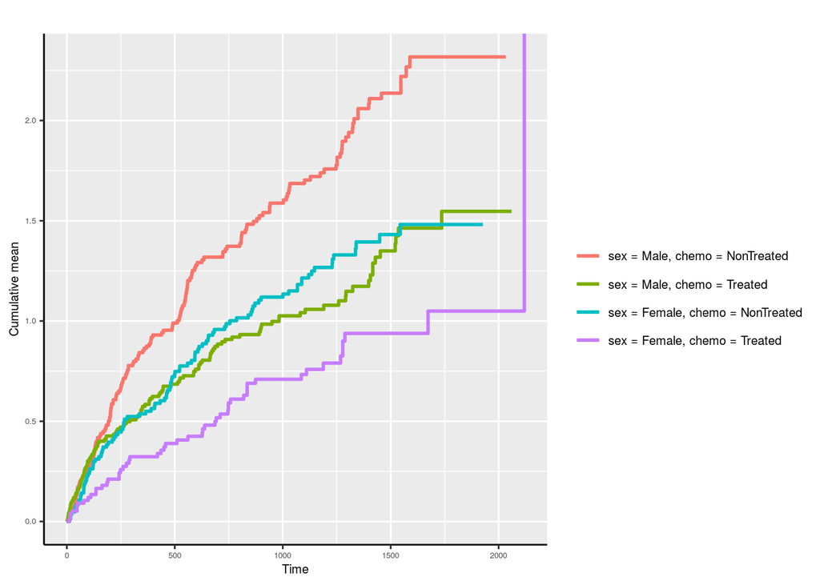

Figure 8: MCF plots grouped by `sex` and `chemo`.

```r
> plotMCF(Recur(t.stop, id, event, death) ~ sex + chemo, data = readmission,
+         onePanel = TRUE, main = "", base_size = 5, legend.position = "right")
```

The same MCF plots can also be produced with the `survfit()` function from the `survival` package or the `mcf()` function from the `reda` package. The `survival` package gives:

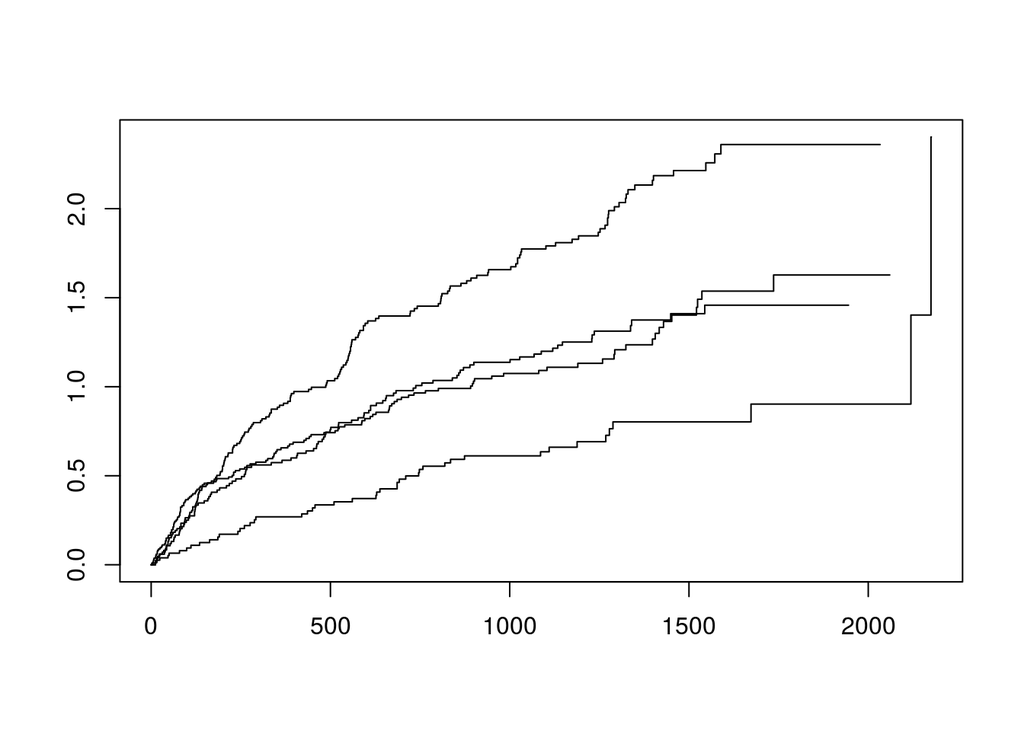

```r
> library(survival)
> plot(survfit(Surv(t.start, t.stop, event) ~ sex + chemo, data = readmission, id = id),
+      cumhaz = TRUE)
```

On the other hand, the `reda` package gives:

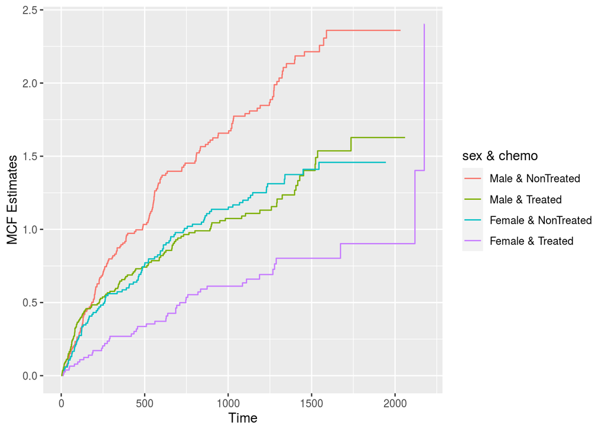

```r
> library(reda)
> plot(mcf(Recur(t.stop, id, event, death) ~ sex + chemo, data = readmission))
```

## Multiple recurrent event types

The functions `plotEvents()` and `plotMCF()` can be used to accommodate recurrent event data with multiple recurrent types. To illustrate this, we generate hypothetical event types and store these in `event2`.

```r
> set.seed(1)
> readmission$event2 <- readmission$event * sample(1:3, 852, TRUE)
```

The `plotEvents()` and `plotMCF()` functions can still be applied when `event` is replaced by `event2`. Different recurrent events will be denoted by different colors and shapes.

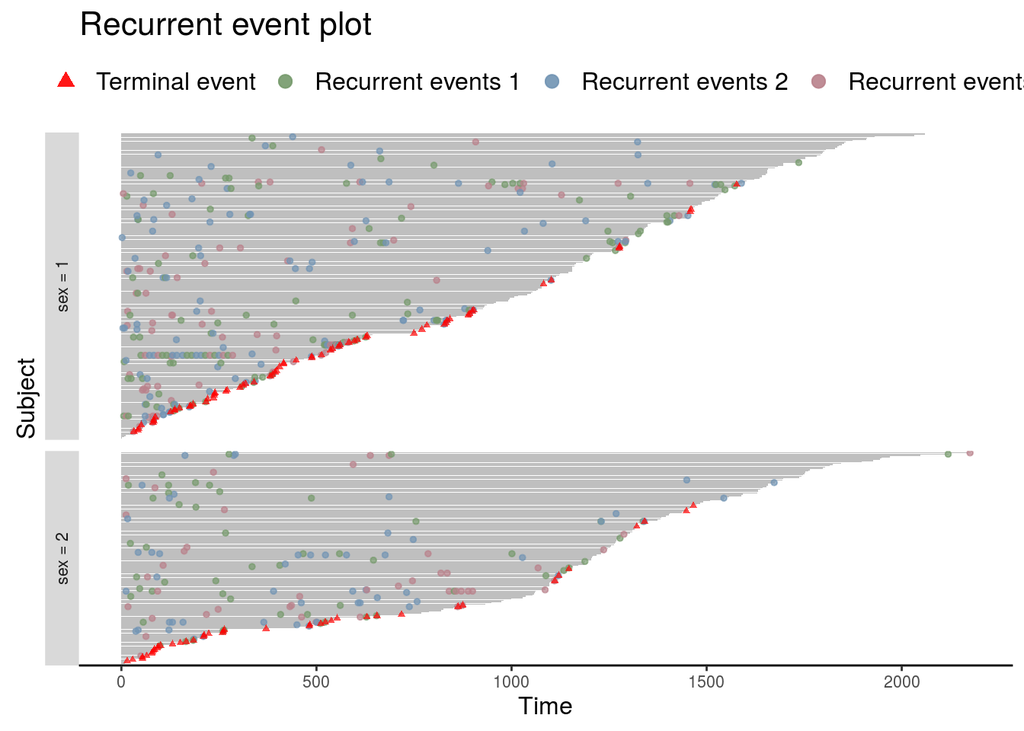

Figure 9: Event plots with multiple recurrent event types.

```r
> plotEvents(Recur(t.stop, id, event2, death) ~ sex, data = readmission, base_size = 8)
```

Default labels can be changed

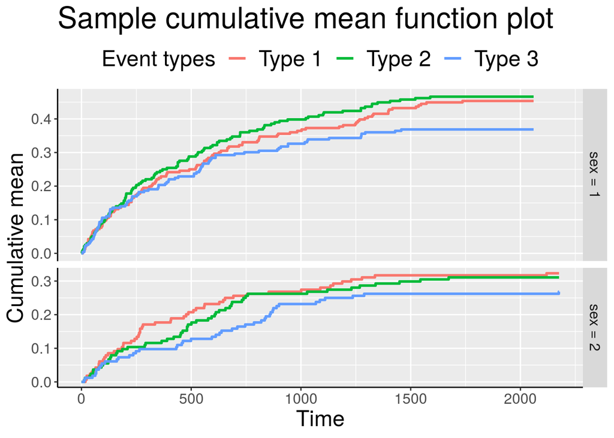

Figure 10: MCF plot with multiple recurrent event types and customized labels.

```r
> plotMCF(Recur(t.stop, id, event2, death) ~ sex, adjrisk = FALSE, data = readmission,
+         recurrent.name = "Event types", recurrent.type = c("Type 1", "Type 2", "Type 3"))
```

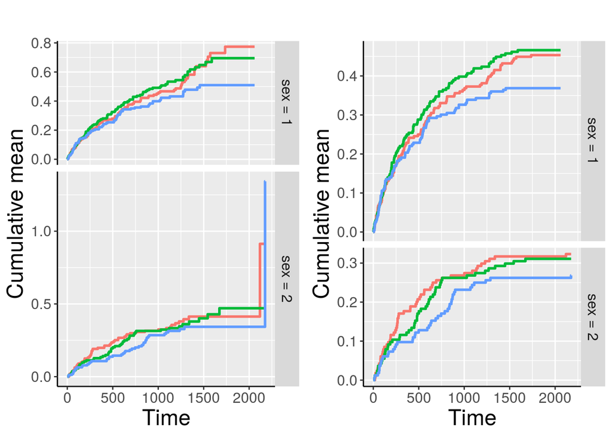

Figure 11: MCF plot with multiple recurrent event types.

```r
> library(ggplot2)
> p1 <- plotMCF(Recur(t.stop, id, event2, death) ~ sex, data = readmission, main = "") +
+   theme(legend.position="none")
> p2 <- plotMCF(Recur(t.stop, id, event2, death) ~ sex, data = readmission,
+               adjrisk = FALSE, main = "") +
+   theme(legend.position="none")
> grid.arrange(p1, p2, ncol = 2)
```

## Reference

Cook, Richard J, and Jerald Lawless. 2007. *The Statistical Analysis of Recurrent Events*. New York: Wiley.

González Ruiz, Juan Ramón, Esteve Fernández Muñoz, Víctor Moreno Aguado, Josepa Ribes Puig, Mercè Peris, Matilde Navarro, Maria Cambray i Amenós, and Borràs Andrés. 2005. “Sex Differences in Hospital Readmission Among Colorectal Cancer Patients.” *Journal of Epidemiology and Community Health, 2005, Vol. 59, Núm. 6, P. 506-511*. BMJ Group.

Nelson, Wayne B. 2003. *Recurrent Events Data Analysis for Product Repairs, Disease Recurrences, and Other Applications*. Vol. 10. SIAM.

Rondeau, Virginie, Yassin Mazroui, and Juan R Gonzalez. 2012. “Frailtypack: An R Package for the Analysis of Correlated Survival Data with Frailty Models Using Penalized Likelihood Estimation or Parametrical Estimation.” *Journal of Statistical Software* 47 (4): 1–28.

Wang, Wenjie, Haoda Fu, and Jun Yan. 2017. *reda: Recurrent Event Data Analysis*. https://CRAN.R-project.org/package=reda.